```python
import numpy as np
import pandas as pd
```

# 1. Data Structure

## 1.1 **Pandas Series**

- A 1-dimensional labeled array
- Supports many data types
- Axis labels $\rightarrow$ index (get and set values by index label)
- Valid argument to most NumPy methods

```python
data0 = pd.Series(data = [1,2,3.,4,5,6,7,8])
data0
```

```
0    1.0
1    2.0
2    3.0
3    4.0
4    5.0
5    6.0
6    7.0
7    8.0
dtype: float64
```

```python
#data1 = pd.Series(data = [1,2,3.,4,5,6,7,8], index = ['a', 'b', 'c', 'd', 'e', 'f', 'g', 'h'])
data1 = pd.Series(data = [1,2,3.,4,5,6,7,8,9], index = ['a', 'b', 'c', 'd', 'e', 'f', 'g', 'h','a'])
data1
```

```
a    1.0
b    2.0
c    3.0
d    4.0
e    5.0
f    6.0
g    7.0
h    8.0
a    9.0
dtype: float64
```

```python
data1.index
data1[4]
data1[[2,4,5]]
#data1['a']
'a' in data1
4 in data0
data1*3
data1**3
data1/2
data1
```

```
a    1.0
b    2.0
c    3.0
d    4.0
e    5.0
f    6.0
g    7.0
h    8.0
a    9.0
dtype: float64
```

## 1.2. **DataFrame**

- A 2-dimensional labeled data structure
- A dictionary of Series objects
  - Columns can be of potentially different types
- Optionally parameters for fine-tuning:
  - index (row labels)
  - columns (column labels)

Pandas provides many constructors to create DataFrames!

```python
data2 = {'GradeS1': pd.Series(data = [70,50,67,84,98],
                              index = ['Maths', 'Art', 'Sport', 'Biology', 'Physics']),
         'GradeS2': pd.Series(data = [90,70,88,78,76,77,87],
                              index = ['Maths', 'Biology', 'Physics', 'chemistry', 'Economics', 'Finance', 'Geology'])}
data2 = pd.DataFrame(data2)
data2
```

|  | GradeS1 | GradeS2 |
| --- | --- | --- |
| Art | 50.0 | NaN |
| Biology | 84.0 | 70.0 |
| Economics | NaN | 76.0 |
| Finance | NaN | 77.0 |
| Geology | NaN | 87.0 |
| Maths | 70.0 | 90.0 |
| Physics | 98.0 | 88.0 |
| Sport | 67.0 | NaN |
| chemistry | NaN | 78.0 |

```python
data2.index
data2.columns
```

```
Index(['GradeS1', 'GradeS2'], dtype='object')
```

```python
d= pd.DataFrame(data2,index=['Maths', 'Physics','Economics'])
d
```

|  | GradeS1 | GradeS2 |
| --- | --- | --- |
| Maths | 70.0 | 90.0 |
| Physics | 98.0 | 88.0 |
| Economics | NaN | 76.0 |

```python
d= pd.DataFrame(data2,index=['Maths', 'Physics','Economics', 'elvira'],
                columns= ('Grade1', 'GradeS2','GradeS1'))
d
```

|  | Grade1 | GradeS2 | GradeS1 |
| --- | --- | --- | --- |
| Maths | NaN | 90.0 | 70.0 |
| Physics | NaN | 88.0 | 98.0 |
| Economics | NaN | 76.0 | NaN |
| elvira | NaN | NaN | NaN |

# 2. Reading and Writing Data

## 2.1 **pandas: Data Ingestion (Reading)**

- Functions such as ‘read_excel’, ‘read_csv’, 'read_json', 'read_html', 'read_sql_query', 'read_sql_table' </b>, etc.

**Syntax: pandas.function(file_directory)**

```python
ddat = pd.read_excel('Climate_Dynamics.xlsx')
ddat
ddat.head()
ddat.head(3)
ddat.tail()
```

|  | Unnamed: 0 | Quiz 1 | Unnamed: 2 | Quiz 2 | Unnamed: 4 | Bonus | Assignment 1 | Unnamed: 7 | Unnamed: 8 | Unnamed: 9 | Assignment 2 | Unnamed: 11 | Unnamed: 12 | Unnamed: 13 | Unnamed: 14 | Extended Quiz | Final Mark | Grade | Unnamed: 18 |
| --- | --- | --- | --- | --- | --- | --- | --- | --- | --- | --- | --- | --- | --- | --- | --- | --- | --- | --- | --- |
| 29 | Remy Twiringiyimana | 8 | 80 | 8 | 80 | 3.0 | 9.5 | 28.5 | 54 | 92 | 18 | 20 | 28 | 28 | 96 | 92 | 90.8 | Distinction | Remy Twiringiyimana |
| 30 | Romain Akpahou | 8 | 80 | 8 | 80 | 10.0 | 9.5 | 29 | 55 | 93.5 | 20 | 20 | 17 | 30 | 91 | 90 | 89.35 | Distinction | Romain Akpahou |
| 31 | Yao Gahounzo | 6 | 60 | 6 | 60 | 10.0 | 9.5 | 29 | 55 | 93.5 | 15 | 20 | 28 | 30 | 97 | 86 | 86.35 | Distinction | Yao Gahounzo |
| 32 | Zeinab Hesham Abd El-ghany | 9 | 90 | 9 | 90 | 17.0 | 9.5 | 29 | 56 | 94.5 | 20 | 20 | 17 | 30 | 91 | 77 | 89.05 | Distinction | Zeinab Hesham Abd El-ghany |
| 33 | Titus | 7 | 70 | 7 | 70 | 22.0 | 10 | 29.5 | 56 | 95.5 | 15 | 20 | 17 | 30 | 91 | 89 | 87.75 | Distinction | Titus |

```python
ddatt = pd.ExcelFile('DefenseSchedule2020forTutors.xlsx')
sheet1_df = pd.read_excel(ddatt, 'For Examiners ')
sheet2_df = pd.read_excel(ddatt, 'For Tutors ')
sheet1_df.head(2)
sheet2_df.head(3)
```

|  | Unnamed: 0 | Wednesday 3rd June | Examiner (purple) and jury (white) | Thursday 4th June | Unnamed: 4 | Friday 5th June | Unnamed: 6 | Unnamed: 7 | Monday 8th June | Unnamed: 9 | Tuesday 9th June | Unnamed: 11 | Wednesday 10th June | Unnamed: 13 |
| --- | --- | --- | --- | --- | --- | --- | --- | --- | --- | --- | --- | --- | --- | --- |
| 0 | 09:00:00. | Angela Nyangate John | Patrice Takam | Yao Gahounzo | Stive | NaN | NaN | NaN | Patrick Pam Peter | Hove | Zeinab | Bourgeois | Leontine | Bemsibom |
| 1 | Tutor | Hove | Blaise, Stive, Bourgeois | Hove | Blaise, Bourgeois | NaN | NaN | NaN | Alex | Bourgeois, Blaise | Jessica | Alex, Blaise | Jessica | Bourgeois |
| 2 | 09:30:00 | Mohamed Maysara Hassan Yagob | Antoine Bogso | Martin De Pores Barindirimana | Denis Ndanguza | Mulengo Kanzoka | Lydie (UR) | NaN | Remy Mugenda Ineza | Hove | Dimitri | Erick Tetsadjio | Jean de Dieu | Bamba |

```python
df = pd.read_json("https://data.smcgov.org/resource/mb6a-xn89.json")
df.head()
```

|  | geography | geography_type | year | less_than_high_school_graduate | high_school_graduate | some_college_or_associate_s_degree | bachelor_s_degree_or_higher | location_1 | :@computed_region_uph5_8hpn | :@computed_region_i2t2_cryp |
| --- | --- | --- | --- | --- | --- | --- | --- | --- | --- | --- |
| 0 | Atherton | Town | 2014-01-01T00:00:00.000 | 13.6 | 12.3 | 2.7 | 3.5 | {'type': 'Point', 'coordinates': [-122.2, 37.4... | 2.0 | 28596 |
| 1 | Colma | Town | 2014-01-01T00:00:00.000 | 6.3 | 6.4 | 10.4 | 2.4 | {'type': 'Point', 'coordinates': [-122.455556,... | 4.0 | 28588 |
| 2 | Foster City | City | 2014-01-01T00:00:00.000 | 11.9 | 9.7 | 2.0 | 2.9 | {'type': 'Point', 'coordinates': [-122.266389,... | 6.0 | 319 |
| 3 | Portola Valley | Town | 2014-01-01T00:00:00.000 | 48.1 | 0.0 | 0.0 | 1.8 | {'type': 'Point', 'coordinates': [-122.218611,... | 14.0 | 28597 |
| 4 | Redwood City | City | 2014-01-01T00:00:00.000 | 16.4 | 10.6 | 6.6 | 3.0 | {'type': 'Point', 'coordinates': [-122.236111,... | 21.0 | 28607 |

```python
data = pd.read_csv('https://archive.ics.uci.edu/ml/machine-learning-databases/breast-cancer-wisconsin/breast-cancer-wisconsin.data')
data.head()
```

|  | 1000025 | 5 | 1 | 1.1 | 1.2 | 2 | 1.3 | 3 | 1.4 | 1.5 | 2.1 |
| --- | --- | --- | --- | --- | --- | --- | --- | --- | --- | --- | --- |
| 0 | 1002945 | 5 | 4 | 4 | 5 | 7 | 10 | 3 | 2 | 1 | 2 |
| 1 | 1015425 | 3 | 1 | 1 | 1 | 2 | 2 | 3 | 1 | 1 | 2 |
| 2 | 1016277 | 6 | 8 | 8 | 1 | 3 | 4 | 3 | 7 | 1 | 2 |
| 3 | 1017023 | 4 | 1 | 1 | 3 | 2 | 1 | 3 | 1 | 1 | 2 |
| 4 | 1017122 | 8 | 10 | 10 | 8 | 7 | 10 | 9 | 7 | 1 | 4 |

## 2.2. Data writing

Save the dataframe in the current directory

```python
#create a dataframe
data2 = {'GradeS1': pd.Series(data = [70,50,67,84,98],
                              index = ['Maths', 'Art', 'Sport', 'Biology', 'Physics']),
         'GradeS2': pd.Series(data = [90,70,88,78,76,77,87],
                              index = ['Maths', 'Biology', 'Physics', 'chemistry', 'Economics', 'Finance', 'Geology'])}
data2 = pd.DataFrame(data2)
#==========================================
# index = False parameter will not write the index values, default is True
#data2.to_csv('data_new.csv', index=True)
#data2.to_csv('data_new.txt', sep='\t', index=True)
data2.to_excel('data_new.xlsx',sheet_name='Sheet1', index = False)
data2.head()
```

|  | GradeS1 | GradeS2 |
| --- | --- | --- |
| Art | 50.0 | NaN |
| Biology | 84.0 | 70.0 |
| Economics | NaN | 76.0 |
| Finance | NaN | 77.0 |
| Geology | NaN | 87.0 |

**Create a folder in the current directory and save the dataframe inside**

```python
#==============================================
# create a folder if it not exists
Name_of_folder = 'dbasc'
import os
if not os.path.exists(Name_of_folder):
    os.makedirs(Name_of_folder)
#==============================================
# index = False parameter will not write the index values, default is True
data2.to_csv(Name_of_folder+'/data_new.csv', index=False)
# data2.to_csv(Name_of_folder+'/mtcars_new.txt', sep='\t', index=False)
# data2.to_excel(Name_of_folder+'/mtcars_new.xlsx',sheet_name='Sheet1', index = False)
```

```python
data1
```

```
a    1.0
b    2.0
c    3.0
d    4.0
e    5.0
f    6.0
g    7.0
h    8.0
a    9.0
dtype: float64
```

# 3. Basic Statistics Summary

**pandas in Descriptive Statistics** Functions such as 'describe()', 'corr()', 'min()', 'max()', 'mode()', 'median()', 'std()', etc.

**Syntax : data_frame.function()**

```python
#data1
data1.describe()
```

```
count    9.000000
mean     5.000000
std      2.738613
min      1.000000
25%      3.000000
50%      5.000000
75%      7.000000
max      9.000000
dtype: float64
```

```python
data2
```

|  | GradeS1 | GradeS2 |
| --- | --- | --- |
| Art | 50.0 | NaN |
| Biology | 84.0 | 70.0 |
| Economics | NaN | 76.0 |
| Finance | NaN | 77.0 |
| Geology | NaN | 87.0 |
| Maths | 70.0 | 90.0 |
| Physics | 98.0 | 88.0 |
| Sport | 67.0 | NaN |
| chemistry | NaN | 78.0 |

```python
data2.describe()
```

|  | GradeS1 | GradeS2 |
| --- | --- | --- |
| count | 5.000000 | 7.000000 |
| mean | 73.800000 | 80.857143 |
| std | 18.143869 | 7.492854 |
| min | 50.000000 | 70.000000 |
| 25% | 67.000000 | 76.500000 |
| 50% | 70.000000 | 78.000000 |
| 75% | 84.000000 | 87.500000 |
| max | 98.000000 | 90.000000 |

```python
data2.loc['Maths',:].describe()
```

```
count     2.000000
mean     80.000000
std      14.142136
min      70.000000
25%      75.000000
50%      80.000000
75%      85.000000
max      90.000000
Name: Maths, dtype: float64
```

```python
data2.corr()
```

|  | GradeS1 | GradeS2 |
| --- | --- | --- |
| GradeS1 | 1.000000 | -0.090784 |
| GradeS2 | -0.090784 | 1.000000 |

```python
data2.max()
```

```
GradeS1    98.0
GradeS2    90.0
dtype: float64
```

```python
data2.cov()
```

|  | GradeS1 | GradeS2 |
| --- | --- | --- |
| GradeS1 | 329.2 | -14.000000 |
| GradeS2 | -14.0 | 56.142857 |

```python
data2.std()
```

```
GradeS1    18.143869
GradeS2     7.492854
dtype: float64
```

```python
data2.mean()
```

```
GradeS1    73.800000
GradeS2    80.857143
dtype: float64
```

```python
df.head()
```

|  | geography | geography_type | year | less_than_high_school_graduate | high_school_graduate | some_college_or_associate_s_degree | bachelor_s_degree_or_higher | location_1 | :@computed_region_uph5_8hpn | :@computed_region_i2t2_cryp |
| --- | --- | --- | --- | --- | --- | --- | --- | --- | --- | --- |
| 0 | Atherton | Town | 2014-01-01T00:00:00.000 | 13.6 | 12.3 | 2.7 | 3.5 | {'type': 'Point', 'coordinates': [-122.2, 37.4... | 2.0 | 28596 |
| 1 | Colma | Town | 2014-01-01T00:00:00.000 | 6.3 | 6.4 | 10.4 | 2.4 | {'type': 'Point', 'coordinates': [-122.455556,... | 4.0 | 28588 |
| 2 | Foster City | City | 2014-01-01T00:00:00.000 | 11.9 | 9.7 | 2.0 | 2.9 | {'type': 'Point', 'coordinates': [-122.266389,... | 6.0 | 319 |
| 3 | Portola Valley | Town | 2014-01-01T00:00:00.000 | 48.1 | 0.0 | 0.0 | 1.8 | {'type': 'Point', 'coordinates': [-122.218611,... | 14.0 | 28597 |
| 4 | Redwood City | City | 2014-01-01T00:00:00.000 | 16.4 | 10.6 | 6.6 | 3.0 | {'type': 'Point', 'coordinates': [-122.236111,... | 21.0 | 28607 |

# 4. Viewing Data

```python
dic = {'Col1':[1, -2, 3, 1, 5, 6, 1, -3, 1, 1],
      'Col2': [4, -3 , 7, 8, 9, 5, 6, 4, -2, 2],
      'Col3': ['Euler', 'A', 'A', 'Euler', 'A', 'A', 'RK4', 'A', 'Euler', 'RK4']}

df = pd.DataFrame(dic, index = ['a', 'b', 'c', 'd', 'e', 'f', 'g', 'h', 'i', 'j'])
df
```

|  | Col1 | Col2 | Col3 |
| --- | --- | --- | --- |
| a | 1 | 4 | Euler |
| b | -2 | -3 | A |
| c | 3 | 7 | A |
| d | 1 | 8 | Euler |
| e | 5 | 9 | A |
| f | 6 | 5 | A |
| g | 1 | 6 | RK4 |
| h | -3 | 4 | A |
| i | 1 | -2 | Euler |
| j | 1 | 2 | RK4 |

## 4.1 The characteristics of a dataframe

```python
df.columns       #Get column names
df.index         # Get dataframe index
df.values        # Get values
df.dtypes        # Get column datatypes
df.shape
```

```
(10, 3)
```

## 4.2 Access, slice and update the values of a dataframe

To access, slice or update the value of a dataframe one can use the methods **loc or iloc**.

**loc** gets rows (or columns) with particular labels from the index. **iloc** gets rows (or columns) at particular positions in the index (so it only takes integers).

### 4.2.1 Selecting pandas data using “iloc”

The **iloc** indexer for Pandas Dataframe is used for **integer-location based indexing / selection by position**.

The iloc indexer syntax is $$\text{data.iloc[<row selection>, <column selection>]},$$

which is sure to be a source of confusion for R users. **iloc** in pandas is used to select rows and columns by number, in the order that they appear in the data frame. You can imagine that each row has a row number from 0 to the total rows (**data.shape[0]**) and **iloc[...]** allows selections based on these numbers. The same applies for columns (ranging from 0 to **data.shape[1]**)

There are two “arguments” to iloc – a row selector, and a column selector. For example:

```python
data = pd.read_csv('https://s3-eu-west-1.amazonaws.com/shanebucket/downloads/uk-500.csv')
# set a numeric id for use as an index for examples.
np.random.seed(21)
data['id'] = [np.random.randint(0,1000) for x in range(data.shape[0])]

data.head(5)
```

|  | first_name | last_name | company_name | address | city | county | postal | phone1 | phone2 | email | web | id |
| --- | --- | --- | --- | --- | --- | --- | --- | --- | --- | --- | --- | --- |
| 0 | Aleshia | Tomkiewicz | Alan D Rosenburg Cpa Pc | 14 Taylor St | St. Stephens Ward | Kent | CT2 7PP | 01835-703597 | 01944-369967 | atomkiewicz@hotmail.com | http://www.alandrosenburgcpapc.co.uk | 969 |
| 1 | Evan | Zigomalas | Cap Gemini America | 5 Binney St | Abbey Ward | Buckinghamshire | HP11 2AX | 01937-864715 | 01714-737668 | evan.zigomalas@gmail.com | http://www.capgeminiamerica.co.uk | 207 |
| 2 | France | Andrade | Elliott, John W Esq | 8 Moor Place | East Southbourne and Tuckton W | Bournemouth | BH6 3BE | 01347-368222 | 01935-821636 | france.andrade@hotmail.com | http://www.elliottjohnwesq.co.uk | 824 |
| 3 | Ulysses | Mcwalters | Mcmahan, Ben L | 505 Exeter Rd | Hawerby cum Beesby | Lincolnshire | DN36 5RP | 01912-771311 | 01302-601380 | ulysses@hotmail.com | http://www.mcmahanbenl.co.uk | 772 |
| 4 | Tyisha | Veness | Champagne Room | 5396 Forth Street | Greets Green and Lyng Ward | West Midlands | B70 9DT | 01547-429341 | 01290-367248 | tyisha.veness@hotmail.com | http://www.champagneroom.co.uk | 48 |

```python
# # Single selections using iloc and DataFrame
# # Rows:
data.iloc[0] # first row of data frame (Aleshia Tomkiewicz) - Note a Series data type output.
data.iloc[1] # second row of data frame (Evan Zigomalas)
data.iloc[-1] # last row of data frame (Mi Richan)
# # Columns:
data.iloc[:,0] # first column of data frame (first_name)
data.iloc[:,1] # second column of data frame (last_name)
data.iloc[:,-1] # last column of data frame (id)
```

```
0      969
1      207
2      824
3      772
4       48
      ...
495    188
496     86
497    584
498    548
499     74
Name: id, Length: 500, dtype: int64
```

```python
data.iloc[:,[-1]] # last column of data frame (id)
```

[output not shown]

500 rows × 1 columns

Multiple columns and rows can be selected together using the **.iloc** indexer.

```python
# # Multiple row and column selections using iloc and DataFrame
data.iloc[0:5] # first five rows of dataframe
data.iloc[:, 0:2] # first two columns of data frame with all rows
data.iloc[[0,3,6,24], [0,5,6]] # 1st, 4th, 7th, 25th row + 1st 6th 7th columns.
data.iloc[0:5, 5:8] # first 5 rows and 5th, 6th, 7th columns of data frame (county -> phone1).
```

|  | county | postal | phone1 |
| --- | --- | --- | --- |
| 0 | Kent | CT2 7PP | 01835-703597 |
| 1 | Buckinghamshire | HP11 2AX | 01937-864715 |
| 2 | Bournemouth | BH6 3BE | 01347-368222 |
| 3 | Lincolnshire | DN36 5RP | 01912-771311 |
| 4 | West Midlands | B70 9DT | 01547-429341 |

### 4.2.2. Selecting pandas data using “loc”

The Pandas loc indexer can be used with DataFrames for two different use cases:

```
- Selecting rows by label/index
- Selecting rows with a boolean / conditional lookup
```

The loc indexer is used with the same syntax as iloc: $$\text{data.loc[<row selection>, <column selection>]}$$

#### a. Label-based / Index-based indexing using .loc

Selections using the loc method are based on the index of the data frame (if any). Where the index is set on a DataFrame, using **df.set_index()**, the .loc method directly selects based on index values of any rows. For example, setting the index of our test data frame to the persons “last_name”:

```python
data = pd.read_csv('https://s3-eu-west-1.amazonaws.com/shanebucket/downloads/uk-500.csv')
# set a numeric id for use as an index for examples.
np.random.seed(21)
data['id'] = [np.random.randint(0,1000) for x in range(data.shape[0])]

data.set_index("last_name", inplace=True)
data.head()
```

| last_name | first_name | company_name | address | city | county | postal | phone1 | phone2 | email | web | id |
| --- | --- | --- | --- | --- | --- | --- | --- | --- | --- | --- | --- |
| Tomkiewicz | Aleshia | Alan D Rosenburg Cpa Pc | 14 Taylor St | St. Stephens Ward | Kent | CT2 7PP | 01835-703597 | 01944-369967 | atomkiewicz@hotmail.com | http://www.alandrosenburgcpapc.co.uk | 969 |
| Zigomalas | Evan | Cap Gemini America | 5 Binney St | Abbey Ward | Buckinghamshire | HP11 2AX | 01937-864715 | 01714-737668 | evan.zigomalas@gmail.com | http://www.capgeminiamerica.co.uk | 207 |
| Andrade | France | Elliott, John W Esq | 8 Moor Place | East Southbourne and Tuckton W | Bournemouth | BH6 3BE | 01347-368222 | 01935-821636 | france.andrade@hotmail.com | http://www.elliottjohnwesq.co.uk | 824 |
| Mcwalters | Ulysses | Mcmahan, Ben L | 505 Exeter Rd | Hawerby cum Beesby | Lincolnshire | DN36 5RP | 01912-771311 | 01302-601380 | ulysses@hotmail.com | http://www.mcmahanbenl.co.uk | 772 |
| Veness | Tyisha | Champagne Room | 5396 Forth Street | Greets Green and Lyng Ward | West Midlands | B70 9DT | 01547-429341 | 01290-367248 | tyisha.veness@hotmail.com | http://www.champagneroom.co.uk | 48 |

Now with the index set, we can directly select rows for different “last_name” values using **.loc[]** – either singly, or in multiples. For example:

```python
data.loc['Veness']
data.loc[['Andrade','Veness']]
```

| last_name | first_name | company_name | address | city | county | postal | phone1 | phone2 | email | web | id |
| --- | --- | --- | --- | --- | --- | --- | --- | --- | --- | --- | --- |
| Andrade | France | Elliott, John W Esq | 8 Moor Place | East Southbourne and Tuckton W | Bournemouth | BH6 3BE | 01347-368222 | 01935-821636 | france.andrade@hotmail.com | http://www.elliottjohnwesq.co.uk | 824 |
| Veness | Tyisha | Champagne Room | 5396 Forth Street | Greets Green and Lyng Ward | West Midlands | B70 9DT | 01547-429341 | 01290-367248 | tyisha.veness@hotmail.com | http://www.champagneroom.co.uk | 48 |

**Selecting single or multiple rows using .loc index selections with pandas. Note that the first example returns a series, and the second returns a DataFrame. You can achieve a single-column DataFrame by passing a single-element list to the .loc operation.**

```python
data.loc[['Veness']]
```

[output not shown]

Select columns with **.loc** using the names of the columns.

```python
data.loc[['Andrade','Veness'], ['first_name','address','city']]
```

| last_name | first_name | address | city |
| --- | --- | --- | --- |
| Andrade | France | 8 Moor Place | East Southbourne and Tuckton W |
| Veness | Tyisha | 5396 Forth Street | Greets Green and Lyng Ward |

When using the .loc indexer, columns are referred to by names using lists of strings, or “:” slices.

You can select ranges of index labels – the selection **data.loc['Bruch':'Julio']** will return all rows in the data frame between the index entries for **'Bruch'** and **'Julio'**. The following examples should now make sense:

```python
# Select rows with index values 'Andrade' and 'Veness', with all columns between 'city' and 'email'
data.loc[['Andrade', 'Veness'], 'city':'email']
# # Select all rows between 'Andrade' and 'Veness', with just 'first_name', 'address' and 'city' columns
data.loc['Andrade':'Veness', ['first_name', 'address', 'city']]
# # Select all rows between 'Andrade' and 'Veness', with all columns between 'city' and 'email'
data.loc['Andrade':'Veness', 'city':'email']
```

| last_name | city | county | postal | phone1 | phone2 | email |
| --- | --- | --- | --- | --- | --- | --- |
| Andrade | East Southbourne and Tuckton W | Bournemouth | BH6 3BE | 01347-368222 | 01935-821636 | france.andrade@hotmail.com |
| Mcwalters | Hawerby cum Beesby | Lincolnshire | DN36 5RP | 01912-771311 | 01302-601380 | ulysses@hotmail.com |
| Veness | Greets Green and Lyng Ward | West Midlands | B70 9DT | 01547-429341 | 01290-367248 | tyisha.veness@hotmail.com |

Note that in the last example, **data.loc[207]** (the row with index value 207) is not equal to **data.iloc[207]** (the 207th row in the data)

```python
data = pd.read_csv('https://s3-eu-west-1.amazonaws.com/shanebucket/downloads/uk-500.csv')
# set a numeric id for use as an index for examples.
np.random.seed(21)
data['id'] = [np.random.randint(0,1000) for x in range(data.shape[0])]

# Change the index to be based on the 'id' column
data.set_index('id', inplace=True)
data.head()
```

| id | first_name | last_name | company_name | address | city | county | postal | phone1 | phone2 | email | web |
| --- | --- | --- | --- | --- | --- | --- | --- | --- | --- | --- | --- |
| 969 | Aleshia | Tomkiewicz | Alan D Rosenburg Cpa Pc | 14 Taylor St | St. Stephens Ward | Kent | CT2 7PP | 01835-703597 | 01944-369967 | atomkiewicz@hotmail.com | http://www.alandrosenburgcpapc.co.uk |
| 207 | Evan | Zigomalas | Cap Gemini America | 5 Binney St | Abbey Ward | Buckinghamshire | HP11 2AX | 01937-864715 | 01714-737668 | evan.zigomalas@gmail.com | http://www.capgeminiamerica.co.uk |
| 824 | France | Andrade | Elliott, John W Esq | 8 Moor Place | East Southbourne and Tuckton W | Bournemouth | BH6 3BE | 01347-368222 | 01935-821636 | france.andrade@hotmail.com | http://www.elliottjohnwesq.co.uk |
| 772 | Ulysses | Mcwalters | Mcmahan, Ben L | 505 Exeter Rd | Hawerby cum Beesby | Lincolnshire | DN36 5RP | 01912-771311 | 01302-601380 | ulysses@hotmail.com | http://www.mcmahanbenl.co.uk |
| 48 | Tyisha | Veness | Champagne Room | 5396 Forth Street | Greets Green and Lyng Ward | West Midlands | B70 9DT | 01547-429341 | 01290-367248 | tyisha.veness@hotmail.com | http://www.champagneroom.co.uk |

```python
i = data.index[1]
print('i = ',i)
#select the row with 'id' = i
data.loc[[i]]
```

```
i =  207
```

| id | first_name | last_name | company_name | address | city | county | postal | phone1 | phone2 | email | web |
| --- | --- | --- | --- | --- | --- | --- | --- | --- | --- | --- | --- |
| 207 | Evan | Zigomalas | Cap Gemini America | 5 Binney St | Abbey Ward | Buckinghamshire | HP11 2AX | 01937-864715 | 01714-737668 | evan.zigomalas@gmail.com | http://www.capgeminiamerica.co.uk |
| 207 | Eva | Joulwan | Central Hrdwr & Elec Corp | 7 Lear Rd | Stroud | Hampshire | GU32 3PQ | 01779-720349 | 01961-802899 | eva.joulwan@gmail.com | http://www.centralhrdwreleccorp.co.uk |
| 207 | Allene | Burau | Allied Plastics | 8 Barlow St #6 | Barlow | Derbyshire | S18 7TH | 01731-825958 | 01260-963065 | allene.burau@hotmail.com | http://www.alliedplastics.co.uk |

```python
data.iloc[[i]]
```

| id | first_name | last_name | company_name | address | city | county | postal | phone1 | phone2 | email | web |
| --- | --- | --- | --- | --- | --- | --- | --- | --- | --- | --- | --- |
| 876 | Madalyn | Dubberly | L & M Industrial Chemicals Inc | 1 Lower Burlington St | Northfleet South Ward | Kent | DA11 8RN | 01974-720949 | 01910-745476 | madalyn.dubberly@gmail.com | http://www.lmindustrialchemicalsinc.co.uk |

### b. Boolean / Logical indexing using .loc

Conditional selections with boolean arrays using $\text{data.loc[<selection>]}$ is the most common method that I use with Pandas DataFrames. With boolean indexing or logical selection, you pass an array or Series of True/False values to the **.loc** indexer to select the rows where your Series has True values.

In most use cases, you will make selections based on the values of different columns in your data set.

For example, the statement $$\text{data[‘first_name’] == ‘Antonio’]}$$ produces a Pandas Series with a True/False value for every row in the ‘data’ DataFrame, where there are “True” values for the rows where the first_name is “Antonio”. These type of boolean arrays can be passed directly to the **.loc** indexer as so:

```python
data = pd.read_csv('https://s3-eu-west-1.amazonaws.com/shanebucket/downloads/uk-500.csv')
# set a numeric id for use as an index for examples.
np.random.seed(21)
data['id'] = [np.random.randint(0,1000) for x in range(data.shape[0])]

data.set_index("last_name", inplace=True)

data.loc[data['first_name'] == 'Antonio']
```

| last_name | first_name | company_name | address | city | county | postal | phone1 | phone2 | email | web | id |
| --- | --- | --- | --- | --- | --- | --- | --- | --- | --- | --- | --- |
| Villamarin | Antonio | Combs Sheetmetal | 353 Standish St #8264 | Little Parndon and Hare Street | Hertfordshire | CM20 2HT | 01559-403415 | 01388-777812 | antonio.villamarin@gmail.com | http://www.combssheetmetal.co.uk | 978 |
| Glasford | Antonio | Saint Thomas Creations | 425 Howley St | Gaer Community | Newport | NP20 3DE | 01463-409090 | 01242-318420 | antonio_glasford@glasford.co.uk | http://www.saintthomascreations.co.uk | 489 |
| Heilig | Antonio | Radisson Suite Hotel | 35 Elton St #3 | Ipplepen | Devon | TQ12 5LL | 01324-171614 | 01442-946357 | antonio.heilig@gmail.com | http://www.radissonsuitehotel.co.uk | 568 |

As before, a second argument can be passed to .loc to select particular columns out of the data frame. Again, columns are referred to by name for the loc indexer and can be a single string, a list of columns, or a slice “:” operation.

```python
data.loc[data['first_name'] == 'Antonio', ['email', 'address','city']]
```

| last_name | email | address | city |
| --- | --- | --- | --- |
| Villamarin | antonio.villamarin@gmail.com | 353 Standish St #8264 | Little Parndon and Hare Street |
| Glasford | antonio_glasford@glasford.co.uk | 425 Howley St | Gaer Community |
| Heilig | antonio.heilig@gmail.com | 35 Elton St #3 | Ipplepen |

Note that when selecting columns, if one column only is selected, the .loc operator returns a Series. For a single column DataFrame, use a one-element list to keep the DataFrame format, for example:

```python
data.loc[data['first_name'] == 'Antonio', 'email']
data.loc[data['first_name'] == 'Antonio', ['email']]
```

[output not shown]

# 5. Basic Operations

## 5.1 Sorting values in the DataFrame

```python
dic = {'Col1':[1, -2, 3, 1, 5, 6, 1, -3, 1, 1],
      'Col2': [4, -3 , 7, 8, 9, 5, 6, 4, -2, 2],
      'Col3': ['Euler', 'A', 'A', 'Euler', 'A', 'A', 'RK4', 'A', 'Euler', 'RK4']}

df = pd.DataFrame(dic, index = ['a', 'b', 'c', 'd', 'e', 'f', 'g', 'h', 'i', 'j'])

# #=============================================================
# #Create a new columns called 'X' and 'Y' in the dataframe df
df['X'] = ['A', 'A', 'A', 'A', 'A', 'B', 'B', 'B', 'B', 'B']
df['Y'] = ['A', 'B', 'A', 'B', 'A', 'B', 'A', 'B', 'A', 'B']
# #============================================================
# df
df.loc['z'] = [1,2,3,4,5]
# #df

df
```

|  | Col1 | Col2 | Col3 | X | Y |
| --- | --- | --- | --- | --- | --- |
| a | 1 | 4 | Euler | A | A |
| b | -2 | -3 | A | A | B |
| c | 3 | 7 | A | A | A |
| d | 1 | 8 | Euler | A | B |
| e | 5 | 9 | A | A | A |
| f | 6 | 5 | A | B | B |
| g | 1 | 6 | RK4 | B | A |
| h | -3 | 4 | A | B | B |
| i | 1 | -2 | Euler | B | A |
| j | 1 | 2 | RK4 | B | B |
| z | 1 | 2 | 3 | 4 | 5 |

```python
df.sort_values(by =['Col1'],ascending=[True], inplace=True)# Sort DataFrame
df.sort_values(by =['Col1', 'Col2'],ascending=[False,False], inplace=True)# Sort DataFrame
df
```

|  | Col1 | Col2 | Col3 | X | Y |
| --- | --- | --- | --- | --- | --- |
| f | 6 | 5 | A | B | B |
| e | 5 | 9 | A | A | A |
| c | 3 | 7 | A | A | A |
| d | 1 | 8 | Euler | A | B |
| g | 1 | 6 | RK4 | B | A |
| a | 1 | 4 | Euler | A | A |
| j | 1 | 2 | RK4 | B | B |
| z | 1 | 2 | 3 | 4 | 5 |
| i | 1 | -2 | Euler | B | A |
| b | -2 | -3 | A | A | B |
| h | -3 | 4 | A | B | B |

## 5.2. Replace NaN Values in Pandas DataFrame

let us consider the following dataframe

```python
data2 = {'GradeS1': pd.Series(data = [70,50,67,84,98],
                              index = ['Maths', 'Art', 'Sport', 'Biology', 'Physics']),
         'GradeS2': pd.Series(data = [90,70,88,78,76,77,87],
                              index = ['Maths', 'Biology', 'Physics', 'chemistry', 'Economics', 'Finance', 'Geology']),
        'GradeS3': pd.Series(data = [69,75,73,87],
                              index = ['Maths', 'chemistry', 'Economics', 'Geology']),
        'GradeS4': pd.Series(data = [90,70,88,78,76,77,87,98,90],
                              index = ['Maths', 'Biology', 'Physics', 'chemistry', 'Economics', 'Finance', 'Geology','Art', 'Sport'])}
data2 = pd.DataFrame(data2)
data2
```

|  | GradeS1 | GradeS2 | GradeS3 | GradeS4 |
| --- | --- | --- | --- | --- |
| Art | 50.0 | NaN | NaN | 98 |
| Biology | 84.0 | 70.0 | NaN | 70 |
| Economics | NaN | 76.0 | 73.0 | 76 |
| Finance | NaN | 77.0 | NaN | 77 |
| Geology | NaN | 87.0 | 87.0 | 87 |
| Maths | 70.0 | 90.0 | 69.0 | 90 |
| Physics | 98.0 | 88.0 | NaN | 88 |
| Sport | 67.0 | NaN | NaN | 90 |
| chemistry | NaN | 78.0 | 75.0 | 78 |

1. For a single column or entire datafame using NumPy:

```python
#Make a deep copy of the data2
data3 = data2.copy()
#Replace NaN by 3 in the column 'GradeS2' of the dataframe using numpy
data3['GradeS2'].replace(np.nan,30, inplace=True)
data3
```

|  | GradeS1 | GradeS2 | GradeS3 | GradeS4 |
| --- | --- | --- | --- | --- |
| Art | 50.0 | 30.0 | NaN | 98 |
| Biology | 84.0 | 70.0 | NaN | 70 |
| Economics | NaN | 76.0 | 73.0 | 76 |
| Finance | NaN | 77.0 | NaN | 77 |
| Geology | NaN | 87.0 | 87.0 | 87 |
| Maths | 70.0 | 90.0 | 69.0 | 90 |
| Physics | 98.0 | 88.0 | NaN | 88 |
| Sport | 67.0 | 30.0 | NaN | 90 |
| chemistry | NaN | 78.0 | 75.0 | 78 |

```python
#Make a deep copy of the data2
data3 = data2.copy()
#Replace NaN by 3 in the entire dataframe using numpy
data3.replace(np.nan,30, inplace=True)
data3
```

|  | GradeS1 | GradeS2 | GradeS3 | GradeS4 |
| --- | --- | --- | --- | --- |
| Art | 50.0 | 30.0 | 30.0 | 98 |
| Biology | 84.0 | 70.0 | 30.0 | 70 |
| Economics | 30.0 | 76.0 | 73.0 | 76 |
| Finance | 30.0 | 77.0 | 30.0 | 77 |
| Geology | 30.0 | 87.0 | 87.0 | 87 |
| Maths | 70.0 | 90.0 | 69.0 | 90 |
| Physics | 98.0 | 88.0 | 30.0 | 88 |
| Sport | 67.0 | 30.0 | 30.0 | 90 |
| chemistry | 30.0 | 78.0 | 75.0 | 78 |

1. For a single column or entire datafame using Pandas:

```python
#Make a deep copy of the data2
data3 = data2.copy()
#Replace NaN by 3 in the column 'GradeS2' using Pandas
data3['GradeS2'].fillna(30, inplace=True)
data3
```

|  | GradeS1 | GradeS2 | GradeS3 | GradeS4 |
| --- | --- | --- | --- | --- |
| Art | 50.0 | 30.0 | NaN | 98 |
| Biology | 84.0 | 70.0 | NaN | 70 |
| Economics | NaN | 76.0 | 73.0 | 76 |
| Finance | NaN | 77.0 | NaN | 77 |
| Geology | NaN | 87.0 | 87.0 | 87 |
| Maths | 70.0 | 90.0 | 69.0 | 90 |
| Physics | 98.0 | 88.0 | NaN | 88 |
| Sport | 67.0 | 30.0 | NaN | 90 |
| chemistry | NaN | 78.0 | 75.0 | 78 |

```python
#Make a deep copy of the data2
data3 = data2.copy()
#Replace NaN by 3 in the entire dataframe using Pandas
data3.fillna(3, inplace=True)
data3
```

|  | GradeS1 | GradeS2 | GradeS3 | GradeS4 |
| --- | --- | --- | --- | --- |
| Art | 50.0 | 3.0 | 3.0 | 98 |
| Biology | 84.0 | 70.0 | 3.0 | 70 |
| Economics | 3.0 | 76.0 | 73.0 | 76 |
| Finance | 3.0 | 77.0 | 3.0 | 77 |
| Geology | 3.0 | 87.0 | 87.0 | 87 |
| Maths | 70.0 | 90.0 | 69.0 | 90 |
| Physics | 98.0 | 88.0 | 3.0 | 88 |
| Sport | 67.0 | 3.0 | 3.0 | 90 |
| chemistry | 3.0 | 78.0 | 75.0 | 78 |

Replace missing values with last valid observation (useful in time series data). For example, temperature does not change drastically compared to previous observation. So better approach is to fill NA is to forward or backward fill. There are mainly two methods available

```python
#Make a deep copy of the data2
data3 = data2.copy()
#Replace NaN by next value in the column 'GradeS1' of the dataframe using Pandas
data3['GradeS1'].fillna(method= 'bfill', inplace=True)
##Note that the last NaN was not replaced because there is no next value for him


##Replace NaN by next value in the column 'GradeS1' of the dataframe using Pandas
data3.fillna(method= 'bfill', inplace=True)
data3
```

|  | GradeS1 | GradeS2 | GradeS3 | GradeS4 |
| --- | --- | --- | --- | --- |
| Art | 50.0 | 70.0 | 73.0 | 98 |
| Biology | 84.0 | 70.0 | 73.0 | 70 |
| Economics | 70.0 | 76.0 | 73.0 | 76 |
| Finance | 70.0 | 77.0 | 87.0 | 77 |
| Geology | 70.0 | 87.0 | 87.0 | 87 |
| Maths | 70.0 | 90.0 | 69.0 | 90 |
| Physics | 98.0 | 88.0 | 75.0 | 88 |
| Sport | 67.0 | 78.0 | 75.0 | 90 |
| chemistry | NaN | 78.0 | 75.0 | 78 |

```python
#Make a deep copy of the data2
data3 = data2.copy()
#Replace NaN by previous value in the column 'GradeS2' of the dataframe using Pandas
data3['GradeS2'].fillna(method= 'ffill', inplace=True)
##Note that the first NaN was not replaced because there is no next value for him


##Replace NaN by previous value in the entire dataframe using Pandas
data3.fillna(method= 'ffill', inplace=True)
data3
```

[output not shown]

## 5.3. Delete NaN Values with Zeros in Pandas DataFrame

```python
#Make a deep copy of the data2
data3 = data2.copy()
#Delete all rows that contain NaN
data3.dropna(axis=0, inplace=True)
data3
```

|  | GradeS1 | GradeS2 | GradeS3 | GradeS4 |
| --- | --- | --- | --- | --- |
| Maths | 70.0 | 90.0 | 69.0 | 90 |

```python
#Make a deep copy of the data2
data3 = data2.copy()
#Delete all columns that contain NaN
data3.dropna(axis=1, inplace=True)
data3
```

|  | GradeS4 |
| --- | --- |
| Art | 98 |
| Biology | 70 |
| Economics | 76 |
| Finance | 77 |
| Geology | 87 |
| Maths | 90 |
| Physics | 88 |
| Sport | 90 |
| chemistry | 78 |

## 5.4. Grouping

Grouping involves one or more of the following steps:

- Splitting the data into groups based on some criteria,
- Applying a function to each group independently,
- Combining the results into a data structure

Let us consider the following data

```python
df = pd.DataFrame({'Name' : ['jack', 'jane', 'jack', 'jane', 'jack', 'jane','jack', 'jane'],
                   'State' : ['SFO', 'SFO', 'NYK', 'CA', 'NYK', 'NYK','SFO', 'CA'],
                   'Grade':['A','A','B','A','C','B','C','A'],
                   'Age' : np.random.randint(24, 50, size=8)})
df
```

|  | Name | State | Grade | Age |
| --- | --- | --- | --- | --- |
| 0 | jack | SFO | A | 42 |
| 1 | jane | SFO | A | 37 |
| 2 | jack | NYK | B | 36 |
| 3 | jane | CA | A | 40 |
| 4 | jack | NYK | C | 38 |
| 5 | jane | NYK | B | 47 |
| 6 | jack | SFO | C | 35 |
| 7 | jane | CA | A | 34 |

Find max age by Name / State

```python
df.groupby(['Name','State']).max()
```

| Name | State | Grade | Age |
| --- | --- | --- | --- |
| jack | NYK | C | 38 |
|  | SFO | C | 42 |
| jane | CA | A | 40 |
|  | NYK | B | 47 |
|  | SFO | A | 37 |

# 6. Plot of a dataframe

```python
data2
```

|  | GradeS1 | GradeS2 | GradeS3 | GradeS4 |
| --- | --- | --- | --- | --- |
| Art | 50.0 | NaN | NaN | 98 |
| Biology | 84.0 | 70.0 | NaN | 70 |
| Economics | NaN | 76.0 | 73.0 | 76 |
| Finance | NaN | 77.0 | NaN | 77 |
| Geology | NaN | 87.0 | 87.0 | 87 |
| Maths | 70.0 | 90.0 | 69.0 | 90 |
| Physics | 98.0 | 88.0 | NaN | 88 |
| Sport | 67.0 | NaN | NaN | 90 |
| chemistry | NaN | 78.0 | 75.0 | 78 |

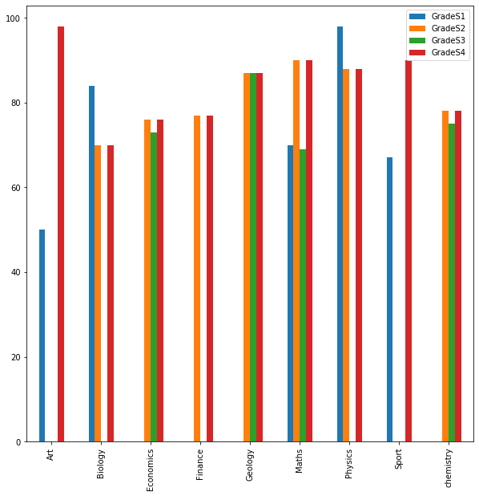

```python
import matplotlib.pyplot as plt
#data2.plot?
data2.plot(figsize=(10,10), kind= 'bar' )
plt.show()
```

```python
data2.plot?
```